# Functions, environments and objects

December 9, 2016

## R programming

An R program consists of a hierarchy of function calls. When the program is executed, function calls are evaluated and replaced by their return values.

R functions are fundamental. They don't do anything before they are called and the call is evaluated. An R function takes a number of *arguments*, and when a function call is evaluated it computes a *return value*.

An R script or R Markdown document is a collection of R function calls, which, when evaluated, compute a desired result.

## R programming

R programming can be

- writing R scripts (for data analysis), interactively running scripts and building reports or other output.
- writing R functions to ease repetitive tasks (avoid copy-paste), to abstract computations, to improve overview by modularization etc.
- developing R packages to ease distribution, to improve usability and documentation, to clarify dependencies etc.

## Writing an R function

A function that counts the number of zeroes in a vector.

```r
countZero <- function(x) {
  nr <- 0
  for(i in seq_along(x)) ## 1:length(x) wrong if length(x) is 0
    nr <- nr + (x[i] == 0)  ## logical coerced to numeric
  nr
}
```

The implementation works in most programming languages:

- Initialize a counter to be 0.
- Loop through the elements of the vector.
- Increment the counter whenever an element equals zero.
- Return the value of the counter.

## Testing an R function

```r
tests <- list(
  c(0, 0, 0, 0, 25),
  c(0, 1, 10, 0, 5, -4, 2.5),
  c(2, 1, 10),
  c())  ## Extreme case
sapply(tests, countZero)
```

```
[1] 4 2 0 0
```

We can manually inspect that the results are correct, or we can do it programmatically.

```r
all(sapply(tests, countZero) == c(4, 2, 0, 0))
```

```
[1] TRUE
```

## Writing an R function, version 2

```r
countZero2 <- function(x)
  sum(x == 0)
```

Testing:

```r
all(sapply(tests, countZero) == sapply(tests, countZero2))
```

```
[1] TRUE
```

```r
identical(
  sapply(tests, countZero),
  sapply(tests, countZero2)
)
```

```
[1] FALSE
```

## Results are equal but not identical!?

```r
typeof(sapply(tests, countZero))
```

```
[1] "double"
```

```r
countZero <- function(x) {
  nr <- 0L  ## counter now of type integer!
  for(i in seq_along(x))
    nr <- nr + (x[i] == 0)
  nr
}
```

```r
typeof(sapply(tests, countZero))
```

```
[1] "integer"
```

## Results are now identical

```r
identical(
  sapply(tests, countZero),
  sapply(tests, countZero2)
)
```

```
[1] TRUE
```

## Vectorized R code

```r
countZero2
```

```
function(x)
  sum(x == 0)
```

- The expression `x == 0` tests each entry of the vector `x` for being equal to 0 and returns a vector of logicals.
- The `sum` function computes and returns the sum of all elements in a vector. Logicals are coerced to integers.
- The vectorized computations are performed by compiled code. They are faster to evaluate than R code.
- Writing vectorized code requires a larger knowledge of R functions.

## Functions

R functions consist of three components:

- The *body* of the function, which is the code in the function.
- The *argument list* that the function takes.
- The *enclosing environment* where the function was created.

## How functions work in principle

- When a function is called, the actual arguments are matched against the *formal arguments*.
- Expressions in the actual argument list are evaluated in the *calling environment*.
- Then the *body* of the function is evaluated.
- Variables that are not arguments or defined inside the body are searched for in the *enclosing environment*.
- The value of the last expression in the body is returned by the function.

## The environments associated with functions

There are several environments associated with a function.

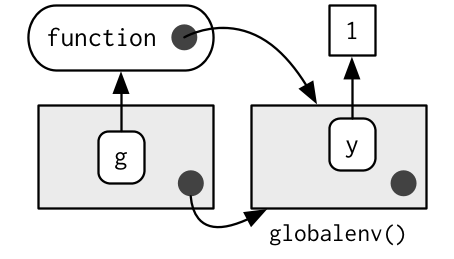

The *binding environment* of `g` is here an environment, whose parent is the global environment.

## Calling and enclosing environments

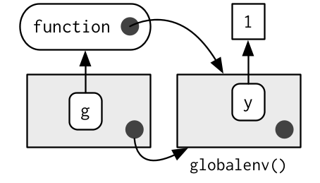

Suppose that `g <- function(z) z + y`.

- What is `g(1)`?
- Does it depend on the *calling environment* of `g`?
- What is the *enclosing environment* of `g`?

## Evaluation environment

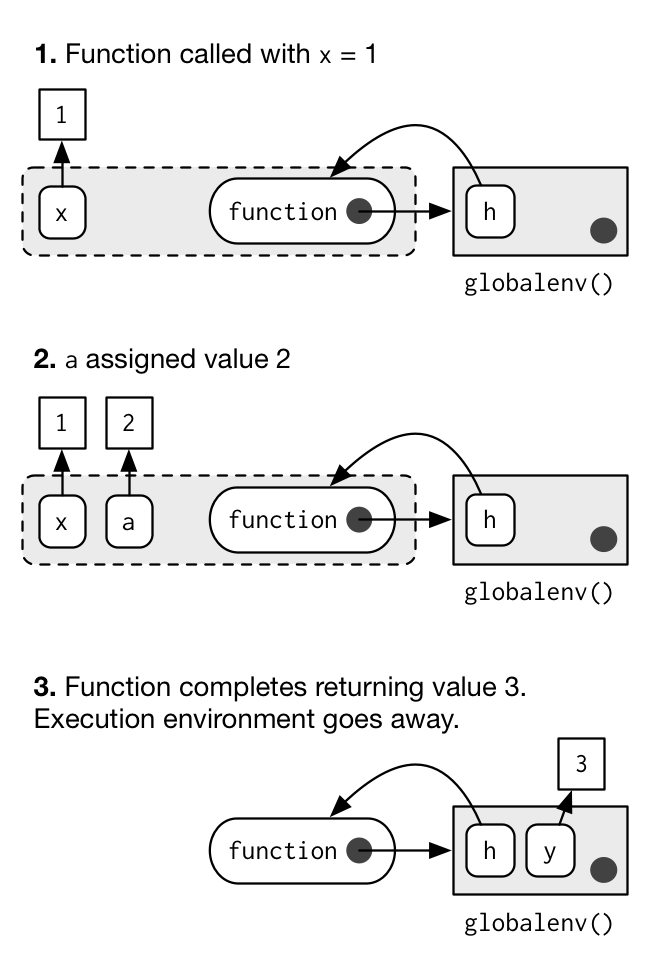

```r
h <- function(x) {
  a <- 2
  x + a
}
y <- h(1)
```

## Scoping rules

For a variable we distinguish between the *symbol* (the `y`) and its value (`2`, say). The rules for finding the symbol are called *scoping* rules, and R implements *lexical scoping*.

Symbols reside in environments, and R searches for a symbol starting from the the *evaluation environment*, then the *enclosing environment* of the function and *not* it's calling environment.

The enclosing environment is by default the environment where the function is defined.

Lexical scoping can appear strange. Setting "global variables" might not always have the "expected effect" (e.g. *dynamic scoping*).

## Namespaces

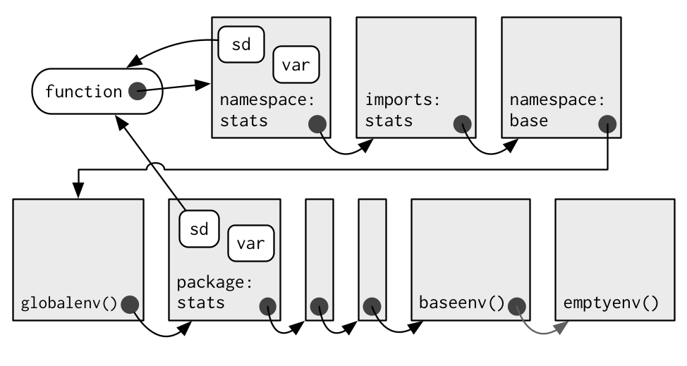

To make sure to use `sd` from package stats write `stats::sd`. To use functions not exported from package stats write `stats:::.Diag` (not recommended).

## S3 in two minutes

- S3 classes are standard data structures (typically lists) with *class labels*.
- It is an informal system. There are no checks of object content.
- One defines a *generic* function via `UseMethod`.
- Then *methods* for specific classes are implemented as standard R functions with the naming convention `f.classname` for a method for class `classname` of the function `f`.
- Widely used to write methods for the generic functions `print`, `plot` and `summary`.

## An example

```r
whichZero <- function(x)
  structure(list(x = x, zeroes = which(x == 0)), class = "knowZeroes")
```

```r
print.knowZeroes <- function(x, ...) ## Method for class 'knowZeroes' objects
  cat(x$x)
```

```r
x <- whichZero(c(4, 2, 0, 0)); x
```

```
4 2 0 0
```

```r
str(x)
```

```
List of 2
 $ x     : num [1:4] 4 2 0 0
 $ zeroes: int [1:2] 3 4
 - attr(*, "class")= chr "knowZeroes"
```

## Counting zeroes for objects that know zeroes

```r
countZero <- function(x)  ## A generic function
  UseMethod("countZero")
```

```r
countZero.knowZeroes <- function(x)
  length(x$zeroes)
```

```r
countZero(x)
```

```
[1] 2
```

## Extracting nonzero values

```r
nonZeroes <- function(x)
  UseMethod("nonZeroes")
nonZeroes.knowZeroes <- function(x)
  x$x[-x$zeroes]
```

```r
nonZeroes(x)
```

```
[1] 4 2
```